# U.S. Natural Disasters Exploratory Analysis

## Analysis of U.S. Natural Disasters 1953-present

### Authors

Isaac Ajeto (ajeto@uw.edu)  
Raymond Smith (smithray@uw.edu)  
Angelina Li (yuchel9@uw.edu)  
Amisha G. (amishg@uw.edu)

### Date

Spring 2022 May 14th, 2022

### Abstract

We analysed U.S. Natural Disaster Declarations since 1953. Our main idea was to tie the occurrence of natural disasters in the U.S. as an effect of climate change over the last 68 years.

### Keywords

Keywords: natural disasters; united states; climate change;

### Introduction

For this project, we will be looking at U.S. Natural Disaster Declarations since 1953. We aim to correlate our findings with climate change so that we can make our readers aware of the harmful effects of climate change. Through this project we aim to answer the following questions:

1. In which year did most disasters occur?

   This question throws light on the year during which most natural disasters occurred. Answer to this question would help us in possibly focusing on certain features of climate change that were most prominent in that year to strengthen the correlation between climate change and natural disasters.
2. What is the change in the amount of natural disasters in Washington State?

   This question helps focus on the change in natural disasters in Washington State. Focusing on a small area can help us understand and correlate the change in natural disasters with features of climate change that are specific to Washington State (such as an astronomical increase in mean temperature),
3. Which U.S. state experienced the greatest increase in natural disasters since 2000?

   This question throws light on the states that are most prone to a certain category of natural disasters. Answer to this question can help disaster managers to increase their presence in certain areas that may require more attention so that rescue operations can be conducted in a timely manner.

### Related Work

The growing occurrence of natural disasters in the United States is one of the most pressing consequences of climate change. According to the United States Geological Survey, “With increasing global surface temperatures the possibility of more droughts and increased intensity of storms will likely occur. As more water vapor is evaporated into the atmosphere it becomes fuel for more powerful storms to develop. More heat in the atmosphere and warmer ocean surface temperatures can lead to increased wind speeds in tropical storms. Rising sea levels expose higher locations not usually subjected to the power of the sea and to the erosive forces of waves and currents” (USGS, 2021).

With the increasing prevalence of natural disasters such as hurricanes, wildfires, or tornados, being able to use aggregate data to visualize the trends and changes in natural disasters will offer insights on our changing world. This sentiment is ubiquitous across much of the scientific world, and there is a bulk of research on the changing nature and frequency of natural disasters. The World Meteorological Organization found in their 2021 report that natural disasters have increased five-fold over the last 50 years, showing that there is a changing trend in the amount of natural disasters (WMO, 2021). NPR has found that not only are disasters becoming more severe, they also have dire effects on our mental health (Pruitt-Young, 2021). A related work to our project is the Natural Disaster article by Hannah Ritchie and Max Roser, which displays natural disaster deaths over time by country and type (Ritchie, 2021). However, we’d like to focus specifically on FEMA declarations in the USA and the frequency of the disasters themselves, not the amount of deaths. This project will fit into this topic and space by supporting findings of increasing natural disasters with a data visualization. Although related works have focused on deaths, we will focus more specifically on the change in frequency and concentration of natural disasters within the United States, offering insights for those in the United States.

### Implications

Finding out the most common categories of natural disasters can help researchers monitor which kinds of disasters need more frequent and urgent care as well as make the readers aware of the consequences of climate change. This also shows what kind of resources need to be prepared to respond when natural disasters happen. Having the adequate amount would prevent wasteful behavior, but also ensures the safety of people in the area. Knowing about the average time between a particular disaster can guide disaster managers and researchers to better have an evacuation plan and urge change makers to act on climate change. We would also look into which U.S states had the most disasters by category. Answering this question would guide disaster managers and policymakers to increase their attention in certain areas that need to be more cautious.

### Limitations & Challenges

One limitation is that the dataset shows previous data of natural disasters in the United States. However, natural phenomena are not predictable. It is difficult for disaster managers to accurately predict future natural disasters. Although they could have a big idea, there are still flaws to the prediction. The second limitation is that the dataset only includes natural disasters with broad categories. Natural disasters include many specific categories and this dataset might not be able to consider those. Policymakers and disaster managers might not be very accurate when using data and taking measures to help specific areas with a particular natural disaster. The data retrieved from the technology might not be the best to predict future natural disasters. There are limitations to the accuracy of technology. This would be a challenge when disaster managers are considering the next move for each area. These are the challenges and limitations that might affect the result of the data.

### Chart 1

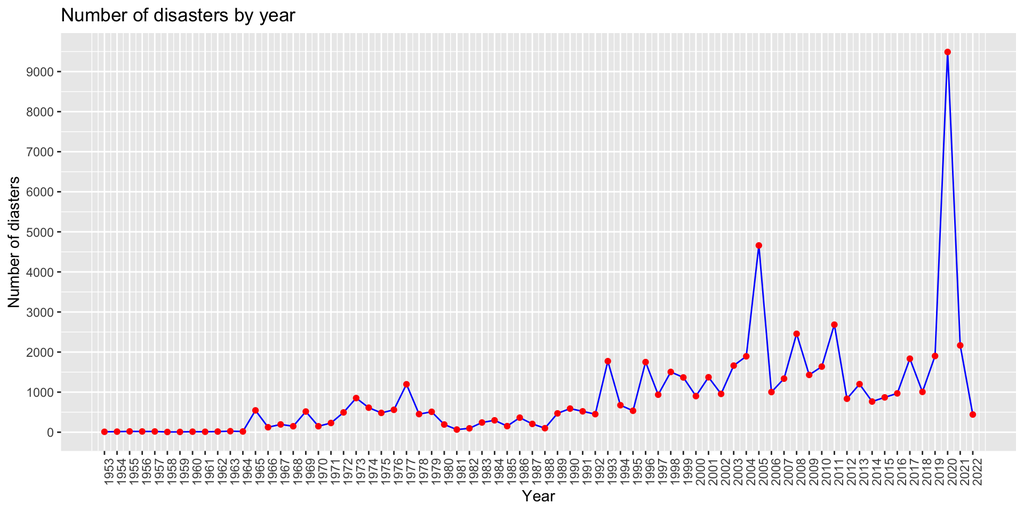

### Citations

1. “How Can Climate Change Affect Natural Disasters?” How Can Climate Change Affect Natural Disasters? | U.S. Geological Survey, https://www.usgs.gov/faqs/how-can-climate-change-affect-natural-disasters#:~:text=With%20increasing%20global%20surface%20temperatures,more%20powerful%20storms%20to%20develop
2. “Climate and Weather Related Disasters Surge Five-Fold over 50 Years, but Early Warnings Save Lives - WMO Report | | UN News.” United Nations, United Nations, https://news.un.org/en/story/2021/09/1098662.
3. Ritchie, Hannah, and Max Roser. “Natural Disasters.” Our World in Data, 3 June 2014, https://ourworldindata.org/natural-disasters.
4. Pruitt-Young, Sharon. “Climate Change Is Making Natural Disasters Worse - along with Our Mental Health.” NPR, NPR, 11 Sept. 2021, https://www.npr.org/2021/09/11/1035241392/climate-change-disasters-mental-health-anxiety-eco-grief.